# Global Analysis

Edoardo Diana

2025-11-21

Cerchiamo qui dei pattern ricorrenti nelle strutture dele networks.

Essi hanno un effetto determinante su come il networked system lavora.

Indice

1 : Connected components and Strongly Connected components

2 : Small-world effect

3 : Power Laws

4 : Assortativity

Domanda A : identifica se l’elite delle pubblicazioni crea un “club” chiuso

5 : Transitivity e Transitivity coefficient

6 : Reciprocity

## 0 : Carico le librerie ed il grafo salvato in precedenza

```r
library(igraph)
library(ggplot2)
library(ggraph)
library(dplyr)
library(tidygraph)
library(knitr)
```

Apro il grafo salvato in precedenza

```r
# Percorso file salvato
processed_dir <- "../data/processed"
graph_file <- file.path(processed_dir, "graph_with_centralities.RData")

# Carico il grafo
if (file.exists(graph_file)) {
  load(graph_file)
  cat("✓ Grafo caricato con successo!\n")

  print(vertex_attr_names(graph))
  cat("  • Nodi:", vcount(graph), "\n")
  cat("  • Archi:", ecount(graph), "\n")

} else {
  stop("ERRORE: File non trovato! Esegui prima il Notebook 02.")
}
```

```
## ✓ Grafo caricato con successo!
##  [1] "name"        "category"    "indegree"    "outdegree"   "pagerank"
##  [6] "closeness"   "betweenness" "authority"   "hub"         "katz"
## [11] "power"
##   • Nodi: 2708
##   • Archi: 5429
```

Creo una copia del grafo e la converto in non diretto

```r
graph_undirected <- as_undirected(graph, mode = "collapse")


cat("Grafo convertito:\n")
```

```
## Grafo convertito:
```

```r
cat("  Nodi:", vcount(graph_undirected), "\n")
```

```
##   Nodi: 2708
```

```r
cat("  Archi:", ecount(graph_undirected), "\n")
```

```
##   Archi: 5278
```

```r
cat("  Densità:", round(ecount(graph_undirected) / (vcount(graph_undirected) * (vcount(graph_undirected) - 1) / 2), 4), "\n")
```

```
##   Densità: 0.0014
```

```r
cat("  Diretto:", is_directed(graph_undirected), "\n\n")
```

```
##   Diretto: FALSE
```

## 1 : Connected Component

La componente connessa di un grafo non diretto è il set massimo di nodi tale che ogni coppia di nodi è connessa da un path.

Il Giant Component riempie la maggior parte della rete.

Per poter ottenere tale Connected Component, ho creato una copia del grafo ma indiretto.

Lavoro qui con il grafo indiretto.

```r
# Trovo le componenti connesse
cc <- components(graph_undirected)

cat("Numero componenti connesse:", cc$no, "\n")
```

```
## Numero componenti connesse: 78
```

```r
cat("Taglia maxima (Giant Component):", max(cc$csize), "nodi\n")
```

```
## Taglia maxima (Giant Component): 2485 nodi
```

```r
cat("Percentuale della Giant Component:", round(100 * max(cc$csize) / vcount(graph_undirected), 1), "%\n")
```

```
## Percentuale della Giant Component: 91.8 %
```

```r
# Nodi che sono nella componente gigante
gc_nodes <- which(cc$membership == which.max(cc$csize))

# Calcolo il diametro sulla giant component e path relativo
gc_subgraph <- induced_subgraph(graph_undirected, gc_nodes)
diam <- diameter(gc_subgraph)
d_path <- get_diameter(gc_subgraph)

cat("Lunghezza del diametro della Giant Component:", diam, "\n")
```

```
## Lunghezza del diametro della Giant Component: 19
```

```r
cat("Numero di nodi nel diametro:", length(d_path), "\n")
```

```
## Numero di nodi nel diametro: 20
```

Plot della Giant Connected Component

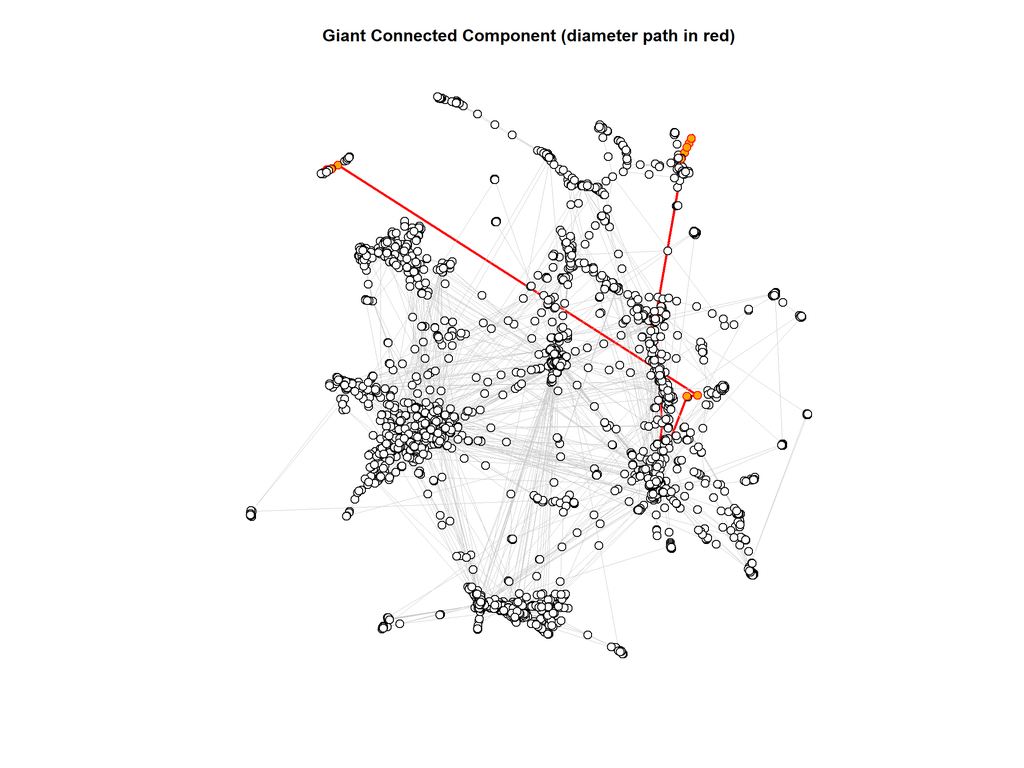

```r
# Impostazioni colore/forma nodi e archi
vcol <- rep("white", vcount(gc_subgraph))
vborder <- rep("black", vcount(gc_subgraph))
vcol[d_path] <- "orange"
vborder[d_path] <- "red"

# Edges del diametro
edges_in_path <- cbind(head(d_path, -1), tail(d_path, -1))
diam_eids <- sapply(1:nrow(edges_in_path), function(i) {
  get.edge.ids(gc_subgraph, vp = c(edges_in_path[i,1], edges_in_path[i,2]), directed = FALSE, error = FALSE)
})

ecol <- rep("grey80", ecount(gc_subgraph))
ecol[diam_eids] <- "red"

ewidth <- rep(0.7, ecount(gc_subgraph))
ewidth[diam_eids] <- 2.8

coords <- layout_with_drl(gc_subgraph)

plot(
  gc_subgraph,
  layout = coords,
  vertex.size = 3,
  vertex.label = NA,
  vertex.color = vcol,
  vertex.frame.color = vborder,
  edge.color = ecol,
  edge.width = ewidth,
  main = "Giant Connected Component (diameter path in red)"
)
```

```r
cat("Nodi lungo il diametro:\n", V(gc_subgraph)$name[d_path], "\n")
```

```
## Nodi lungo il diametro:
##  1154074 103430 75318 141171 179702 424540 48555 48550 3229 1108834 4330 6913 646286 16819 643069 14090 1103016 14083 62676 312409
```

### Strongly Connected Components

Nel caso di un grafo diretto, abbiamo questa nozione.

2 nodi sono nello stesso Strongly Connected Components se sono a vicendnda raggiungibili mediante un directed path.

Formano una partizione del set dei vertici e definiscono una relazione di equivalenza tra nodi.

Questo è dovuto al fatto che quando un paper ne cita un altro, questo citato sarà stato per forza scritto in passato.

La citation network è aciclica, quindi non ci aspettiamo SCC di grandi dimensioni.

```r
scc <- components(graph, mode = "strong")

cat("Numero Strongly Connected Components:", scc$no, "\n")
```

```
## Numero Strongly Connected Components: 2526
```

```r
cat("Taglia massima SCC:", max(scc$csize), "\n")
```

```
## Taglia massima SCC: 13
```

## 2 : Small-world effect

Lo Shortest Path tra 2 nodi (Geodesic Path) in un grafo è il path con il numero minore di edges.

La lunghezza di tale path è detta Shortest Distance (Geodesic Distance).

Lo Small-World effect mi dice che la Shortest Distance è tipicamente sorprendentemente corta.

Uso qui il grafo non diretto ottenuto in precedenza.

```r
# Distanza media tra i nodi (gradi di separazione)
avg_dist <- mean_distance(graph_undirected)
cat("Distanza media (gradi di separazione):", round(avg_dist, 2), "\n")
```

```
## Distanza media (gradi di separazione): 6.31
```

```r
# Diametro della rete (shortest path più lungo)
diam <- diameter(graph_undirected)
cat("Diametro (shortest path più lungo):", diam, "\n")
```

```
## Diametro (shortest path più lungo): 19
```

```r
# Cammino del diametro
diam_path <- get_diameter(graph_undirected)
cat("Nodi attraversati dal diametro:", V(graph_undirected)$name[diam_path], "\n")
```

```
## Nodi attraversati dal diametro: 1154074 103430 75318 141171 179702 424540 48555 48550 3229 1108834 4330 6913 646286 16819 643069 14090 1103016 14083 62676 312409
```

```r
# Statistiche delle distanze geodetiche
dist_table <- distance_table(graph_undirected)
cat("Numero coppie finite:", sum(dist_table$res), "\n")
```

```
## Numero coppie finite: 3086918
```

```r
paths <- dist_table$res
min_dist <- min(which(paths > 0))
max_dist <- max(which(paths > 0))
cat("Lunghezza minima:", min_dist, "\n")
```

```
## Lunghezza minima: 1
```

```r
cat("Lunghezza massima:", max_dist, "\n")
```

```
## Lunghezza massima: 19
```

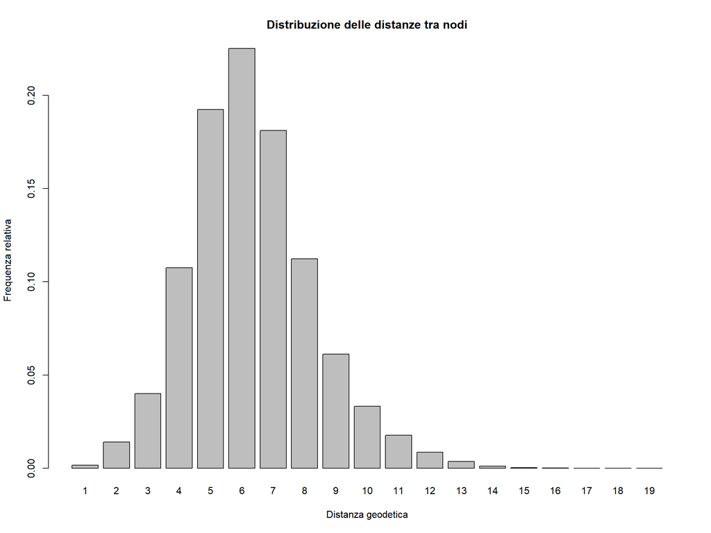

```r
# Istogramma/frequenza delle distanze
paths <- dist_table$res
names(paths) <- as.character(1:length(paths))
barplot(
  paths / sum(paths),
  xlab = "Distanza geodetica",
  ylab = "Frequenza relativa",
  main = "Distribuzione delle distanze tra nodi"
)
```

```r
distance_table(graph_undirected)
```

```
## $res
##  [1]   5278  43166 123625 331651 593566 694750 559174 346515 189033 102424
## [11]  54501  26686  11264   3807   1101    296     65     15      1
##
## $unconnected
## [1] 578360
```

## 3 : Power Laws

La quantità pk è la frazione di nodi che hanno grado k.

Essa è anche la probabilità che un nodo scelto randomicamente abbia gardo k.

Le varie quantità pk rappresentano la degree distribution della rete.

In molti reti reali, la Degree Distrubition è asimmtrica (skewed).

La Skewness misura la simmetria di una distribuzione.

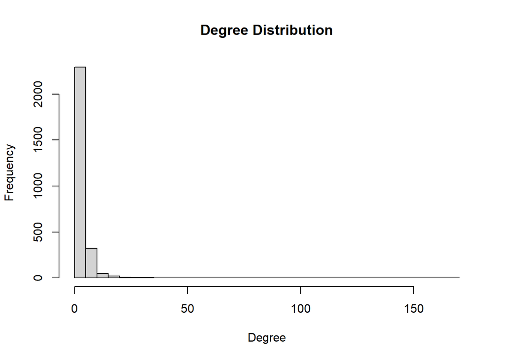

```r
skewness = function(x) mean( (x - mean(x))^3 ) / sd(x)^3

deg <- degree(graph_undirected)
hist(deg, breaks = 50, main = "Degree Distribution", xlab = "Degree", ylab = "Frequency")
```

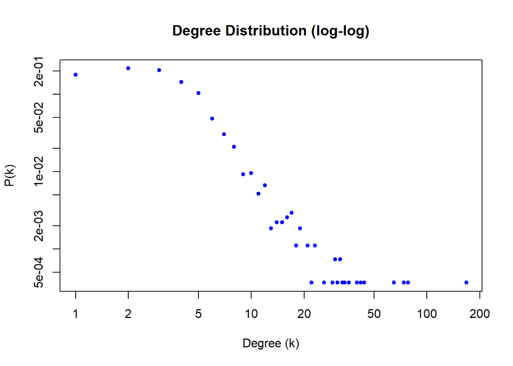

```r
# log-log plot
dd <- degree_distribution(graph_undirected)
degrees <- 1:(length(dd) - 1)
valid <- dd[-1] > 0
plot(
  degrees[valid], dd[-1][valid],
  log = "xy",
  col = "blue", pch = 20,
  xlab = "Degree (k)", ylab = "P(k)",
  main = "Degree Distribution (log-log)"
)
```

```r
cat("Skewness distribuzione:", skewness(deg), "\n")
```

```
## Skewness distribuzione: 15.26298
```

```r
cat("Degree min:", min(deg), "\n")
```

```
## Degree min: 1
```

```r
cat("Degree max:", max(deg), "\n")
```

```
## Degree max: 168
```

```r
cat("Fraction nodes with degree 1:", mean(deg == 1), "\n")
```

```
## Fraction nodes with degree 1: 0.179099
```

```r
print(summary(deg))
```

```
##    Min. 1st Qu.  Median    Mean 3rd Qu.    Max.
##   1.000   2.000   3.000   3.898   5.000 168.000
```

Una skewness così alta dimostra una distribuzione fortemente asimmetrica.

Infatti pochi nodi hanno grado molto alto (hub), mentre la maggior parte ha grado basso.

## 4 : Assortativity

Le persone preferiscono stare con altri che sono in qualche modo simili a loro (Homophily).

Ogni nodo della rete può essere assegnato ad un tipo in base al valore della caratteristica per quel nodo.

La rete è Assortative se una frazione significante delle edges corre tra vertici dello stesso tipo.

La Modularity è una misura della Assortativity di una rete.

Posso normalizzare la Modularità andando a dividere per il massimo valore che essa può assumere.

Una misura dell’ assortative mixing in base ad una caratteristica scalare è la Covarianza.

L’Assortativity Coefficient è la misura della normalized assortativity, definita come il Coefficiente di correlazione di Pearson.

### Assortativity by degree

Questo coefficiente misura la tendenza dei nodi con grado simile a collegarsi tra loro.

I valori possibili vanno da -1 a +1.

```r
# Calcolo il grado di ciascun nodo
d <- degree(graph_undirected)

# Creo la edge list
edge <- as_edgelist(graph_undirected, names = FALSE)

# Creo due vettori: per ogni edge i gradi dei due estremi (l, r)
l <- c(edge[,1], edge[,2])
r <- c(edge[,2], edge[,1])
dl <- d[l]
dr <- d[r]

# Calcolo l'assortativity, ossia pearson tra i gradi dei vertici collegati
assortativity_degree <- cor(dl, dr)

cat("Assortativity by degree (Pearson correlation):", assortativity_degree, "\n")
```

```
## Assortativity by degree (Pearson correlation): -0.06587087
```

-0.06587087 questo valore indica che la rete è tale che i nnodi con molti collegamenti tendono a collegarsi leggermente più spesso con nodi a basso grado, piuttosto che con altri hub.

### Assortativity by categorical attribute, category

Essa misura quanto i paper della stessa categoria tendono a collegarsi tra loro.

```r
assortativity_category <- assortativity_nominal(graph_undirected, as.factor(V(graph_undirected)$category), directed = FALSE)
cat("Assortativity by category:", assortativity_category, "\n")
```

```
## Assortativity by category: 0.7710854
```

(0.77): Fortissima omofilia di categoria: le citazioni avvengono molto spesso tra nodi della stessa categoria.

Ma questo era facil intuirlo fin dall’inizio.

## Domanda A : identifica se l’elite delle pubblicazioni crea un “club” chiuso.

In pratica se i paper (nodi) ad alta centralità (PageRank) tendono a citare/ricevere citazioni da altri paper ugualmente centrali, o la rete di influenze è più sparsa.

Se l’assortatività è positiva, allora l’elite dei paper centrali cita prevalentemente altri paper influenti, creando una sorta di “elite club” della rete della conoscenza scientifica.

```r
pr <- page_rank(graph_undirected)$vector
edge <- as_edgelist(graph_undirected, names = FALSE)
l <- c(edge[,1], edge[,2])
r <- c(edge[,2], edge[,1])
pl <- pr[l]
prr <- pr[r]
assortativity_pagerank <- cor(pl, prr)
cat("Assortatività rispetto al PageRank:", assortativity_pagerank, "\n")
```

```
## Assortatività rispetto al PageRank: -0.07957071
```

Non si forma un “elite club”.

I paper centrali non creano una sottorete chiusa e autoreferenziale, ma sono piuttosto ponte verso molti altri paper meno centrali.

Il valore è vicino a zero, quindi si tratta di una tendenza debole.

## 5 : Transitivity e Transitivity coefficient

Indica quanto la edge relation è transitiva (se x connesso a y, e y connesso a z -> x connesso a z).

Tre nodi x, y e z tali che x e z sono amici di y, è una Triade centrata in y.

Essa è detta aperta se manca il legame tra x e z.

Il Transitivity coefficient per una rete corrisponde alla frazione di triadi che sono chiuse.

Ossia la probabilità media che 2 persone con un amico in comune siano a loro volta amici.

L’idea è di calcolare il Transitivity Coefficient sul grafo non diretto.

Ottengo il Transitivity Coefficient

```r
transitivity(graph_undirected, type = "global")
```

```
## [1] 0.09349726
```

Il risultato indica che circa il 10% delle triadi sono closed.

Istogramma della distribuzione locale dei clustering

L’asse X rappresenta il valore del clustering locale di ciascun nodo, cioè la frazione di possibili triangoli localmente chiusi per quel nodo.

```r
transitivity(graph_undirected, type = "average")
```

```
## [1] 0.2931819
```

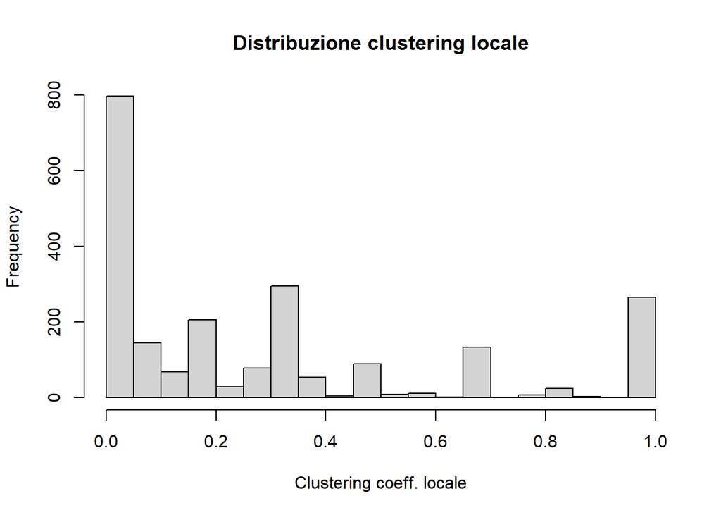

```r
clust_loc <- transitivity(graph_undirected, type="local")

hist(clust_loc, breaks=30, main="Distribuzione clustering locale", xlab="Clustering coeff. locale")
```

In media, ogni nodo ha un clustering locale del 29%: cioè quasi un terzo dei possibili triangoli centrati su ciascun nodo risultano effettivamente chiusi.

Il fatto che il valore sia più alto del globale indica che ci sono nodi (o comunità locali) in cui il clustering è particolarmente elevato (i “grappoli” o zone di forte collaborazione reciproca).

Esistono però anche molti nodi con clustering locale esattamente 1 (cioè piccoli gruppi chiusi, come coautori che si autocitano spesso oppure community molto coese).

La distribuzione è sparsa, ci sono nodi con clustering locale intermedio, segno della presenza di sottostrutture locali e micro-comunità.

## 6 : Reciprocity

E’ una misura di quanto è probabile che un nodo verso cui ho un arco uscente, ne abbia a sua volta uno verso di me.

Posso computarla usando la traccia del quadrato della matrice di adiacenza del grafo.

Il problema è che le reti acicliche come quella che abbiamo qui son caratterizzate dal fatto che tecnicamente 2 paper non potrbbero citarsi a vicenda.

Se nel mio articolo ne cito un altro, esso sarà sicuramente uscito prima del mio e dunque non può ricambiare la citazione.